# The track selection menu

Starting in this lesson, we will design a mouse and touch interface to let the player select tracks.

The player will be able to navigate the tracklist with a horizontal drag motion and press the “go” button to play the selected track, represented by a colored square.

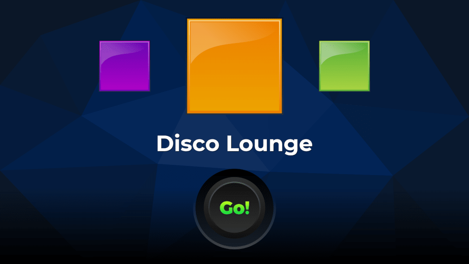

There is quite a lot to cover, so we will split the whole menu creation in three parts.

In this one, we will design the menu and add the ability to play a track by clicking a button. In the next one, we’ll generate the tracklist procedurally. And in the third one, we’ll implement a carousel to select different tracks by touching and dragging on the screen.

## Designing the track selection menu

Let’s start creating the menu that will display the selected track at the top, its name, and a button to play the game.

Create a new scene with a

[figure not shown]

`Control` node as its root named *UITrackSelector*. You can save it in the `RhythmGame/UI/TrackSelector` directory.

First, we’ll dedicate an area at the top to displaying the available audio tracks.

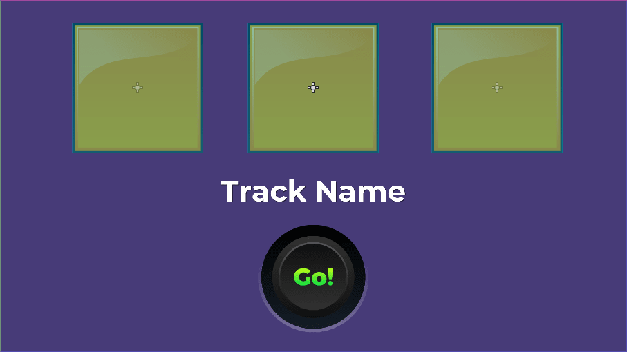

We will use 2D nodes for that as we will manipulate them in code. We want to smoothly animate them when the player drags their finger over a certain area.

You can mix

[figure not shown]

`Control` and 2D nodes in Godot’s interface scenes without problems. It depends on your needs.

*In Godot 3, animating UI nodes is not easy or convenient. It can be much easier to do so with 2D nodes.*

*The only limitation when you don’t use UI nodes inside an interface is that you lose their layout and anchoring features. So if we wanted our tracklist to resize with the game window, we would have to write some extra code.*

Create a new

[figure not shown]

`Position2D` node named *TrackCarousel* and center it around the screen’s top. I set its position to `(960, 240)`.

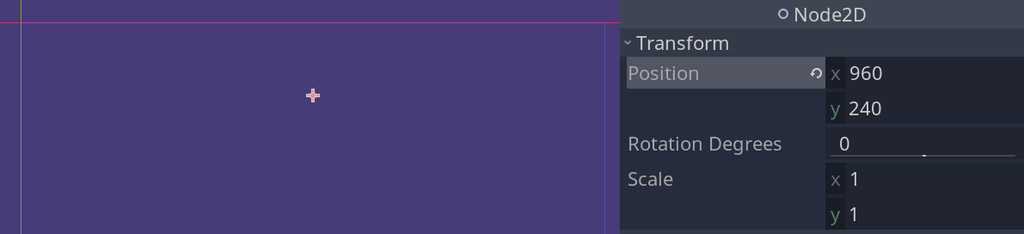

As a child, create a new

[figure not shown]

`Node2D` named *TrackTiles*. We will populate it with a row of track icons, and when dragging, we will move this node to have the tracks slide horizontally. We’ll see how in the next lesson.

Then, as a child of *TrackTiles*, add an

[figure not shown]

`Area2D` named *TrackTile* with a

[figure not shown]

`Sprite` and

[figure not shown]

`CollisionShape2D` as its children.

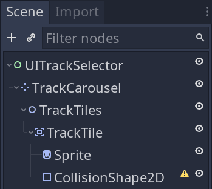

You can assign the `icon_cephalopod.png` file to the *Sprite*’s *Texture*.

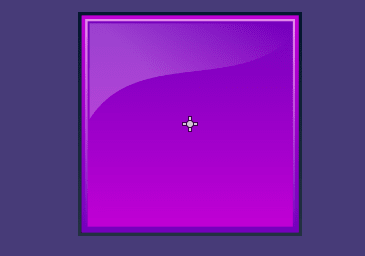

Then, set the *CollisionShape2D*’s *Shape* to a new *RectangleShape2D* that encompasses the sprite. We will use this area to detect the track the player selected.

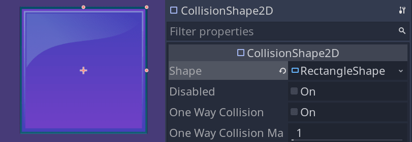

That’s the upper area set up. Let’s now move to the label and button.

To display the track’s name, we instantiate the `LabelCustom` scene as a child of *UITrackSelector* and rename it to *TrackName*.

We can anchor the node to the center of the viewport using the *Layout -> HCenter Wide* option. You can give it the placeholder text “Cephalopod” to preview how it will look.

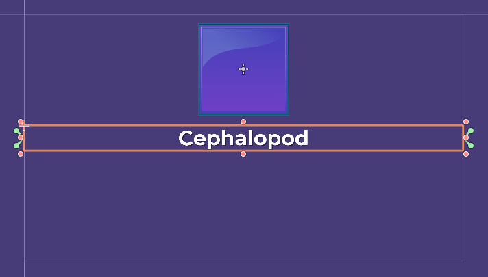

Finally, add a *TextureButton* named *GoButton* as a child of *UITrackSelector*.

We prepared two textures for its normal and hover states. Assign the `button_go_hover.png` to the node’s *Textures -> Hover* property, and `button_go_normal.png` to its *Textures -> Normal* texture.

And we anchor it to the bottom of the screen using the *Layout -> Center Bottom* option. You can move the node up so it isn’t stuck against the viewport’s bottom edge.

That’s it for the menu’s layout; it should roughly look like this.

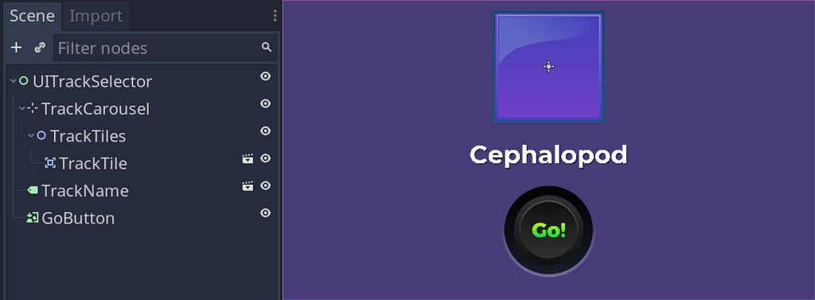

Next, we move on to adding support for audio playback.

## Audio playback

We want to give the player an audio preview of the selected track. To do so, we add two new nodes as children of *UITrackSelector*: an

[figure not shown]

`AudioStreamPlayer` and an

[figure not shown]

`AnimationPlayer`.

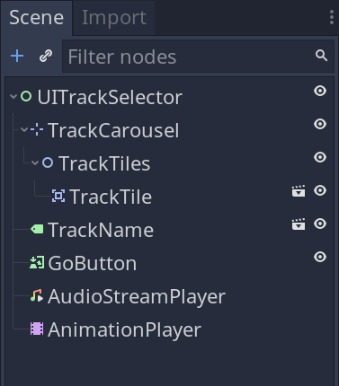

The

[figure not shown]

`AudioStreamPlayer` should have a *Volume Db* of `-80` Db by default so it’s not audible. We will use animation to fade in the sound.

Speaking of which, in the

[figure not shown]

`AnimationPlayer`, we create two animations, `fade_in_track` and `fade_out_track`, which we’ll use to transition between soundtracks smoothly.

The `fade_in_track` animation should have one keyframe for the

[figure not shown]

`AudioStreamPlayer`’s *Volume Db* at half a second with a value of `0` Db.

Be sure to set the animation mode to capture by going to the right of the animation track and clicking the leftmost icon.

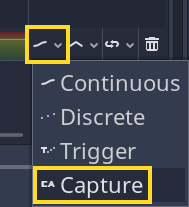

The capture mode automatically interpolates from the property’s current value to the first keyframe. It does so linearly, which isn’t ideal for audio volume, but it’ll do for now.

Your animation should look like this.

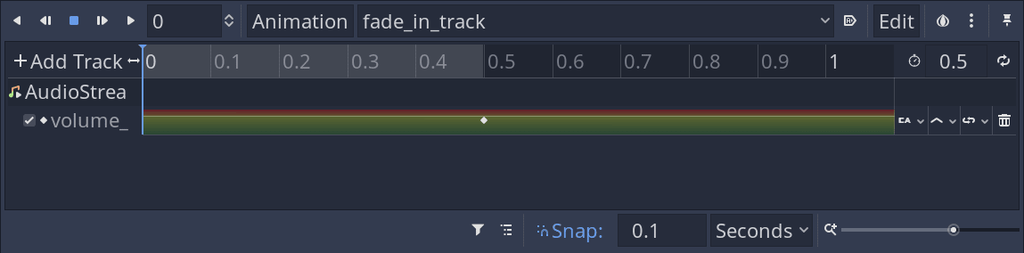

For the `fade_out_track` animation, you can do the same with one keyframe at `0.5` seconds but set to a value of `-80` DB. Once again, the animation track should be set to capture mode.

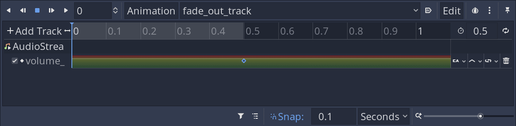